# Lab 09

### Lab 09: Customize the tool in ArcGIS Pro

- This lab covers the topics about how to create a customized tool in ArcGIS Pro.
- Please provide your code answers directly below each question.
- Make sure to run all cells so that the answers are stored. Once completed, submit the .ipynb file (**ensuring that all answers are included**) to Canvas by **midnight (11:29 PM) on Nov 10**.
- This lab is worth a total of **65 points** and contributes **6.5%** toward the final grade.
1. Modify the code to detect and highlight areas with density values in the lower percentile range based on user input. (65 pts)

For example, if the user inputs 30%, the output should highlight areas with density values within the bottom 30% (i.e., 0% to 30%) of the entire dataset. To verify the functionality, test the code by using input thresholds of 10% and 30% to generate example maps highlighting areas in these lower density ranges.

The following example map demonstrates regions with values in the lower 10% and 30%, respectively.

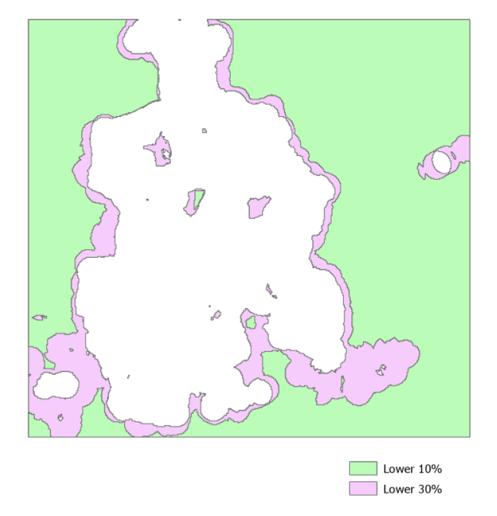